# CADENA Maria, Homework 2

The purpose of this homework is to build an image recognition system, using transfer learning and fine-tuning based on pre tuned convolutional neural networks on ImageNet.  
*Exercise 1*  
*1. What is ImageNet?*

ImageNet database of images that is organized hierarchically according to the WordNet hierarchy. The database currently holds an average of over five hundred images per node and was designed for use in visual object recognition software research.

*2. How many different kinds of cheese can you find in ImageNet?*

The cheese node holds 37 different subclasses.

*3. What is the best classifier on ImageNet and what is its error rate?*

According to www.independent.co.uk GOOGLE AI built a model in 2017 with accuracy of 82.7%. What is interesting about this model is that it was built by the AutoML system itself. The system automated the process of creating machine learning algorithms and created the neural network classifier that outperforms by 1.2% all the previous models created by humans.

*Exercise 2*  
Build an image recognition system for a 1000 everyday object categories (ImageNet ILSVRC) using Keras and TensorFlow.  
*1. Install keras*

```r
#install_keras()
library(keras)
```

*2. Define ResNet50 as your model and check it’s architecture.*  
We define our model with the resnet50 application from the keras and set the weights of each layer as the pretrained values for ImageNet.

```r
model <- application_resnet50(weights = 'imagenet')
#summary(model)
```

ResNet50 is a 50 layer Residual Network. This type of netwok manage to perform great classification because of its depth. Not all models architectures allow this type of depth, since according to [1], with network depth increasing, accuracy gets saturated and then degrades rapidly.  
ResNet50 is composed by a convolution block and it additionally adds a shortcut connection (identity mapping) that is set to avoid the degradation problem.

*a) What are the other pre trained networks available with keras?*  
This are the other networks pretrained that can be found in the keras library:  
- Xception: Deep convolutional neural network architecture inspired by Inception  
- VGG16: Released by Oxford, 16 layers. Commonly used for transfer learning models.  
- VGG19: Released by Oxford, 19 layers.  
- InceptionV3: Ensemble of 4 models and multi-crop evaluation  
- InceptionResNetV2: Ensemble of three residual and one Inception-v4 model  
- MobileNet: Depthwise separable convolutions to build light weight deep neural networks.  
- DenseNet: Connects each layer to every other layer in a feed-forward fashion  
- NASNet: GOOGLE AI Network. Mentioned before as the best model for image classification  
*3. Open an image representing a single object*  
I donwloaded the picture of a cassette from Imagenet.

[figure not shown]

```r
library("jpeg")
img_path <- "/Users/mariafcadena/Documents/Master Degree/Polytechnique/Advanced Machine Learning/Homework 2/cassette.jpg"
img <- image_load(img_path, target_size = c(224,224))
jj <- readJPEG(img_path,native=TRUE)
plot(0:1,0:1,type="n",ann=FALSE,axes=FALSE)
rasterImage(jj,0,0,1,1)
```

*4. Reshape the image to fit the input format of your model.*

```r
x <- image_to_array(img)
x <- array_reshape(x, c(1, dim(x)))
```

*5. Preprocess the input*

```r
x <- imagenet_preprocess_input(x)
```

*6. Get the model predictions*

```r
preds <- model %>% predict(x)
```

*7. Display the top 5 recognized objects. Do you find the one represented on your image?*

```r
imagenet_decode_predictions(preds, top = 5)[[1]]
```

```
##   class_name class_description        score
## 1  n02978881          cassette 9.897590e-01
## 2  n02979186   cassette_player 6.828916e-03
## 3  n04392985       tape_player 3.404845e-03
## 4  n04125021              safe 5.133002e-06
## 5  n04372370            switch 7.616266e-07
```

As we can see the class description with the higher score is the one that perfectly explains the object that I selected. We can therefore confirm the effectiveness of this pretrained network.

*Exercise 3*  
Based on your previous work, build an binary object recognition (only two objects) by transfer learning and fine tuning.  
*1. Choose two classes and import data*  
I am going to build a model that differentiates pictures of parrots from pictures of guacomole

```r
# Training and testing directories
train_dir <- "/Users/mariafcadena/Documents/Master Degree/Polytechnique/Advanced Machine Learning/Homework 2/Images/Train"
validation_dir <- "/Users/mariafcadena/Documents/Master Degree/Polytechnique/Advanced Machine Learning/Homework 2/Images/Validation"
```

*2. Transfer learning Model*

The idea behind transfer learning is to take a previously trained neural network, keep all the blocks as they were trainend but altering the upper layer so it fits the purpose of our model. In this case we want to create a classifier that distinguishes between pictures of parrots and guacamole We are going to take the previously trained net VGG16, this network is composed by 16 layers, the upper layer is a classifier trained to distinguish the 1000 categories that are avilable in Imagenet. Since we only need a 2 class classifier, we are going to create a new fully connected classifier and train it with our data.  
First, we load the images in the train set and validation set. We set the class mode binary since we want to differentiate between two classes of images.

```r
train_datagen = image_data_generator( rescale = 1/255,
                                      rotation_range = 40,
                                      width_shift_range = 0.2,
                                      height_shift_range = 0.2,
                                      shear_range = 0.2,
                                      zoom_range = 0.2,
                                      horizontal_flip = TRUE,
                                      fill_mode = "nearest" )

train_set <- flow_images_from_directory(  train_dir,
                                          train_datagen,
                                          target_size = c(150, 150),
                                          batch_size = 20,
                                          class_mode = "binary"
)

validation_set <- flow_images_from_directory( validation_dir,
                                              target_size = c(150, 150),
                                              batch_size = 20,
                                              class_mode = "binary")
```

Then we load the pretrained image model VGG16, with the weights for imagenet.

```r
pretrained_model <- application_vgg16( weights = "imagenet",
                                       include_top = FALSE,
                                       input_shape = c(150, 150, 3))
```

Now we add a new layer(classifier) and then freeze the weights of the pretrained model, in order to keep the knowledge of all the pretrained convolutional blocks.

```r
new_model <-  keras_model_sequential() %>%
              pretrained_model %>%
              layer_flatten() %>%
              layer_dense(units = 256, activation = "relu") %>%
              layer_dense(units = 1, activation = "sigmoid")
```

As we mention before, we want to transfer the knowledge of the pretrained model to our new model. That is why before training the new model with our data, we need to set the layers from the VGG16 model as non-trainable, this will ensure that we keep the weights of the previous training of the model, and that we are only going to train the upper layer we just added.

```r
#Trainable weigths before freezing
length(new_model$trainable_weights)
```

```
## [1] 30
```

```r
#Trainable wieghts after freezing
freeze_weights(pretrained_model)
length(new_model$trainable_weights)
```

```
## [1] 4
```

Finally we set the optimizer and train the new model with our data.

```r
new_model %>% compile(  loss = "binary_crossentropy",
                        optimizer = optimizer_rmsprop(lr = 2e-5),
                        metrics = c("accuracy"))

convergence <- new_model %>% fit_generator( train_set,
                                        steps_per_epoch = 8,
                                        epochs = 20,
                                        validation_data = validation_set,
                                        validation_steps = 5)
```

Here we can see the convergence of our new model.

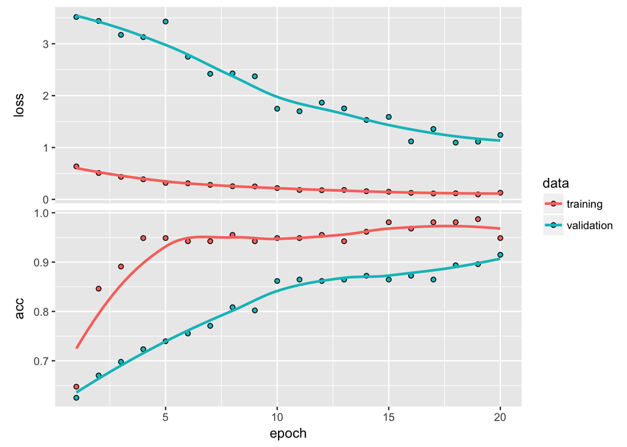

```r
plot(convergence)
```

As we can see after ploting that our validation accuracy convergeces to a rate of approximately 92%, which is consiferably high taking in to account that we used just a few amount of data to train the final layer (classifier)  
We can check graphically with a couple of examples the performance of our new model.

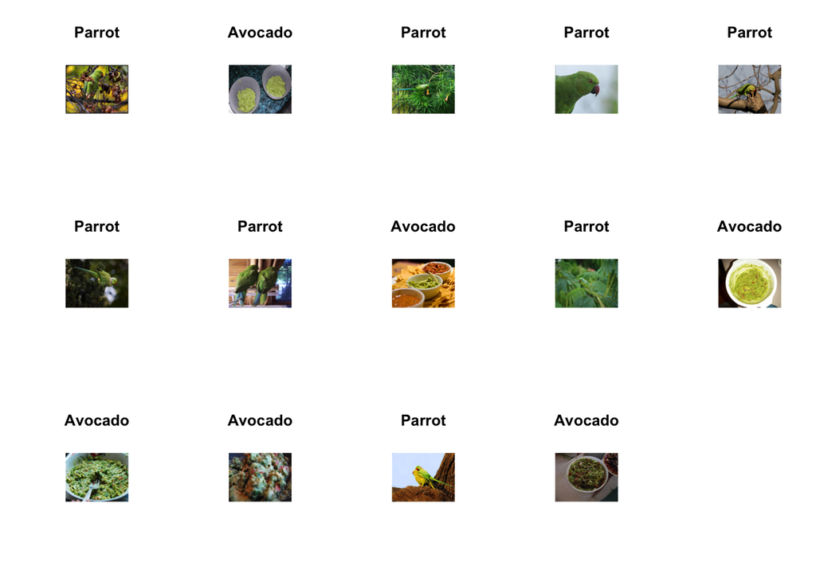

```r
library("jpeg")
library(ggplot2)
library(grid)
library(gridExtra)

images<-list.files("/Users/mariafcadena/Documents/Master Degree/Polytechnique/Advanced Machine Learning/Homework 2/Images/Test")
j=0
results<-c()
par(mfrow=c(3,5))
for (i in images) {
  img_path<-paste("/Users/mariafcadena/Documents/Master Degree/Polytechnique/Advanced Machine Learning/Homework 2/Images/Test/",i,sep = "")
  img <- image_load(img_path, target_size = c(150,150))
  x <- image_to_array(img)
  x <- array_reshape(x, c(1, dim(x)))
  x <- imagenet_preprocess_input(x)
  y<-new_model %>% predict(x)
  if(y[,1]<0.5){y2="Avocado"} else {y2="Parrot"}
  results<-c(results,y2)
  jj <- readJPEG(img_path,native=TRUE)
  plot(0:1,0:1,type="n",ann=FALSE,axes=FALSE) +title(main=y2)
  rasterImage(jj,0,0,1,1)
}
```

We see how good the model performs with this set of images. 100% of them are well clasified.  
*3. Fine tuning Model*

Another technique that can be used for image classification is Fine-tuning. This technique consist of using a pretrained model and adding a new layer (usually a classifier). What differs from other models is that in fine-tuning we jointly train the newly added part of the model and some of high level or upper layers. The term fine-tuning is used because it slightly adjusts the more abstract representations of the pretrained model, in order to make them more relevant for the specific problem that we aim to solve.  
Since we already created a model with a new classifier for the transfer learning exercise. We can reuse this model but we will unfreeze the weights of the last convolutional block. Since the lower layers in the convolutional base encode more-generic, reusable features. On the other hande, the higher layers encode more-specialized features.

```r
unfreeze_weights(new_model, from = "block5_conv1")
```

No we can proceed to train the unfreezed weights of the last convolutional block and the fully connected classifier

```r
new_model %>% compile(  loss = "binary_crossentropy",
                        optimizer = optimizer_rmsprop(lr = 2e-5),
                        metrics = c("accuracy"))

convergence_2 <- new_model %>% fit_generator( train_set,
                                        steps_per_epoch = 8,
                                        epochs = 20,
                                        validation_data = validation_set,
                                        validation_steps = 5)
```

In the next plot we can verify the performance of our model

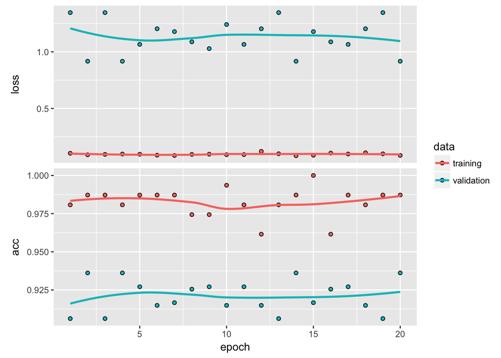

```r
plot(convergence_2)
```

We can see that the performance is affected by the tuning of the upper convolutional layer. Since we only have few images to train and validate the results the weights are not properly set and hence the performance of the model is not as smooth as it is in the transfer learning model.  
*3. Is it better to do transfer learning and fine tuning or both?*

We can see that in fine tuning we are altering the layers that are extracting the features of our images. Since this layers deal with this type of information they requiere a larger set of data in order to be able to trained properly the weights in the neural network. In this case since we only have a few tens of images we can see how it is possible to lose some knowledge when we try to fit this convolutional feature extraction blocks to our set of data. So for this type of cases is more efficient to use transfer learning and train a simpler classifier than fine-tuning some other layers from a pretrained model, since the lack of data will lead to a deterioration of the model and higher computational time.

*References*  
[1] *Deep Residual Learning for Image Recognition*. HE Kaiming, ZHANG Xiangyu, REN Shaoqing, SUN Jian. Microsoft Research. Dic 10 2015. [2] *Image Classification on Small Datasets with Keras*. https://tensorflow.rstudio.com/blog/keras-image-classification-on-small-datasets.html 14 Dic 2017